# TP3: survie et estimation non-paramétrique, BINET Thomas

**Important:** Ceci est un document R notebook. En cliquant sur knit vous aurez le choix entre un document html, pdf ou word. Le TP doit être rendu sous la forme d’un fichier NOM_prenom_RegLog.html. Il est à remettre dans moodle. CTRL+Alt+i permet d’ouvrir une cellule de code compilable.

# 1 Fonctions utiles

Le package `asaur` contient une dizaine de datasets de survie. Nous allons notamment travailler sur les datasets `gastricXelox` et `pharmacoSmoking` dont vous pouvez avoir un aperçu grâce à la fonction `glimpse` (package `tidyverse`)

```r
rm(list=ls())
library(survival)
library(asaur)
library(ggfortify)
head(gastricXelox)
```

```
##   timeWeeks delta
## 1         4     1
## 2         8     1
## 3         8     1
## 4         8     1
## 5         9     1
## 6        11     1
```

```r
head(pharmacoSmoking)
```

```
##    id ttr relapse         grp age gender     race employment yearsSmoking
## 1  21 182       0   patchOnly  36   Male    white         ft           26
## 2 113  14       1   patchOnly  41   Male    white      other           27
## 3  39   5       1 combination  25 Female    white      other           12
## 4  80  16       1 combination  54   Male    white         ft           39
## 5  87   0       1 combination  45   Male    white      other           30
## 6  29 182       0 combination  43   Male hispanic         ft           30
##   levelSmoking ageGroup2 ageGroup4 priorAttempts longestNoSmoke
## 1        heavy     21-49     35-49             0              0
## 2        heavy     21-49     35-49             3             90
## 3        heavy     21-49     21-34             3             21
## 4        heavy       50+     50-64             0              0
## 5        heavy     21-49     35-49             0              0
## 6        heavy     21-49     35-49             2           1825
```

1. Créer une fonction permettant de calculer l’estimateur de Kaplan-Meier pour la fonction de survie. Elle devra pouvoir fonctionner avec les datasets `pharmacoSmoking` et `gastricXelox`. On pourra utiliser les fonctions (order et unique). Effectuer une représantation graphique de vos résultats.

$$\hat{S}(t)=\underset{i:ti<t}{\prod}(1-\dfrac{d_i}{Y_i}),$$

$d_i$ le nombre de décé au temps $t_i$ et $Y_i$ le nombre de personne à risque juste avant le temps $t_i.$

```r
estim.Kaplan.Meier<-function(temps,delta){
  PROD=1
  li=list()
  n=length(temps)
  Temps=sort(unique(temps))
  for (t in Temps) {
    nb_mort=sum(temps <= t) #nbr de personne qui on relapse avant t
    nb_mort_avant=sum(temps < t)
    c_i=sum(temps==t & delta==0)
    di=sum(delta[temps==t])
    #di=sum(temps==t)- c_i #gens mort au temps t
    Y_i=sum(temps>=t)

    PROD=PROD*(1-di/Y_i)
    li=append(li,PROD)
  }
  return(li)
}
```

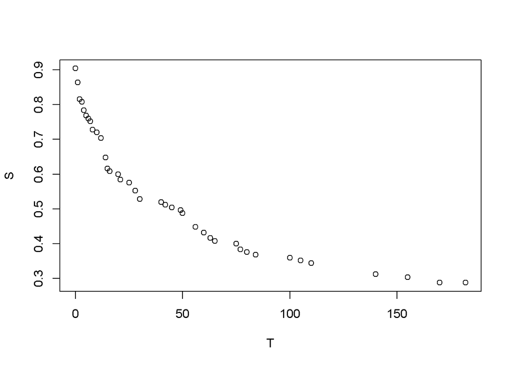

```r
#Pour pharmacoSmoking
S=estim.Kaplan.Meier(pharmacoSmoking$ttr,pharmacoSmoking$relapse)
T=sort(unique(pharmacoSmoking$ttr))
plot(T,S)
```

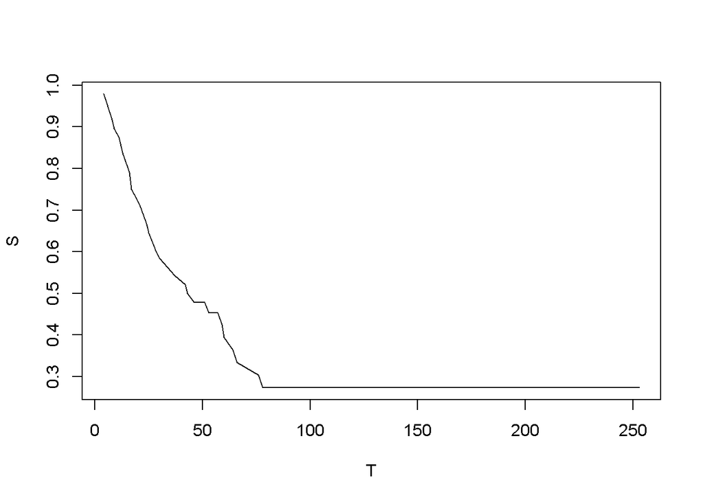

```r
# gastriXelox

S=estim.Kaplan.Meier(gastricXelox$timeWeeks,gastricXelox$delta)
T=sort(unique(gastricXelox$timeWeeks))
plot(T,S,'l')
```

3. Créer une fonction permettant de calculer l’estimateur de Greenwood de la variance. Effectuer une représantation graphique de vos résultats.

   ```r
   estim.Greenwood<-function(temps,delta){
     PROD=1
     S=list()
     VarS=list()
     n=length(temps)
     Temps=sort(unique(temps))
     sum=0
     for (t in Temps) {
       nb_mort=sum(temps <= t) #nbr de personne qui on relapse avant t
       nb_mort_avant=sum(temps < t)
       c_i=sum(temps==t & delta==0)
       #di=nb_mort- nb_mort_avant
       di=sum(temps==t)- c_i #gens mort au temps t
       Y_i=n- nb_mort_avant
       PROD=PROD*(1-di/Y_i)
       sum=sum+di/(Y_i*(Y_i-di))
       S=append(S,PROD)
       VarS=append(VarS,sum*PROD^2)
     }
     return(list(S=S,VarS=VarS))
   }
   ```

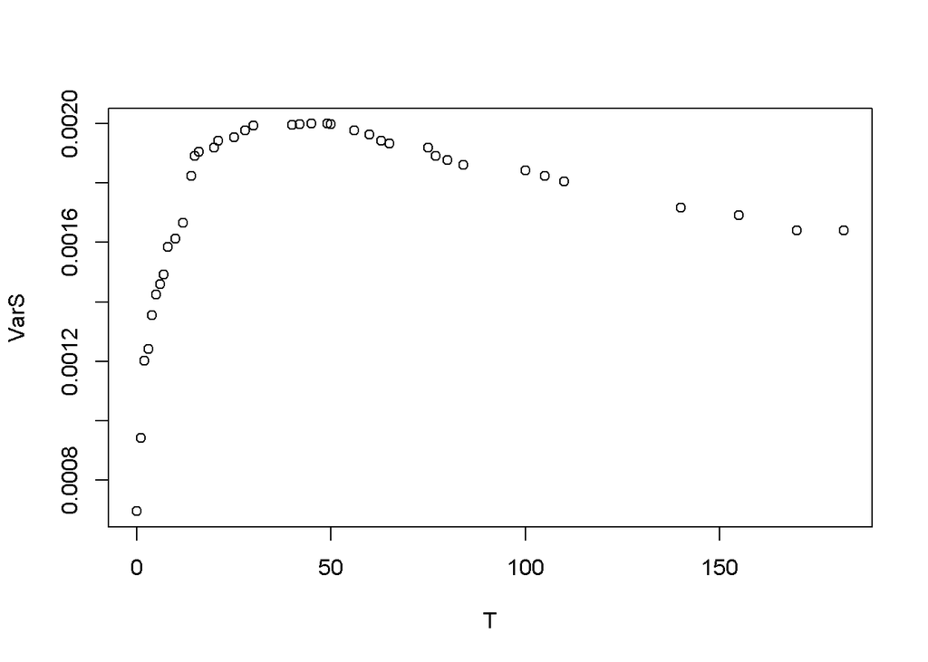

   ```r
   #pharmacoSmoking
   tab=estim.Greenwood(pharmacoSmoking$ttr,pharmacoSmoking$relapse)
   S=tab$S
   VarS=tab$VarS
   T=sort(unique(pharmacoSmoking$ttr))
   plot(T,VarS)
   ```

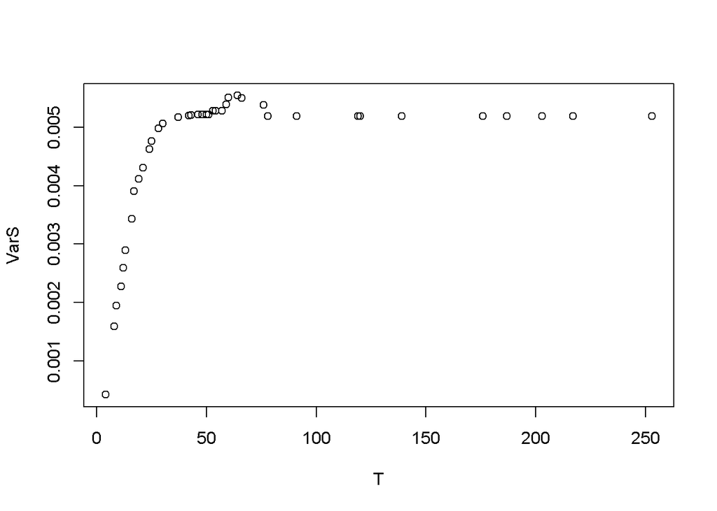

   ```r
   tab2=estim.Greenwood(gastricXelox$timeWeeks,gastricXelox$delta)
   S=tab2$S
   VarS=tab2$VarS
   T=sort(unique(gastricXelox$timeWeeks))
   plot(T,VarS)
   ```

4. Créer une fonction permettant de calculer les estimateurs de Nelson-Aalen et de Breslow du risque cumulé. Effectuer une représantation graphique de vos résultats.

       Breslow=append(Breslow,-SumBreslow)
       Nelson=append(Nelson,SumNelson)
     }
     return(list(Breslow=Breslow,Nelson=Nelson))
   }
   ```

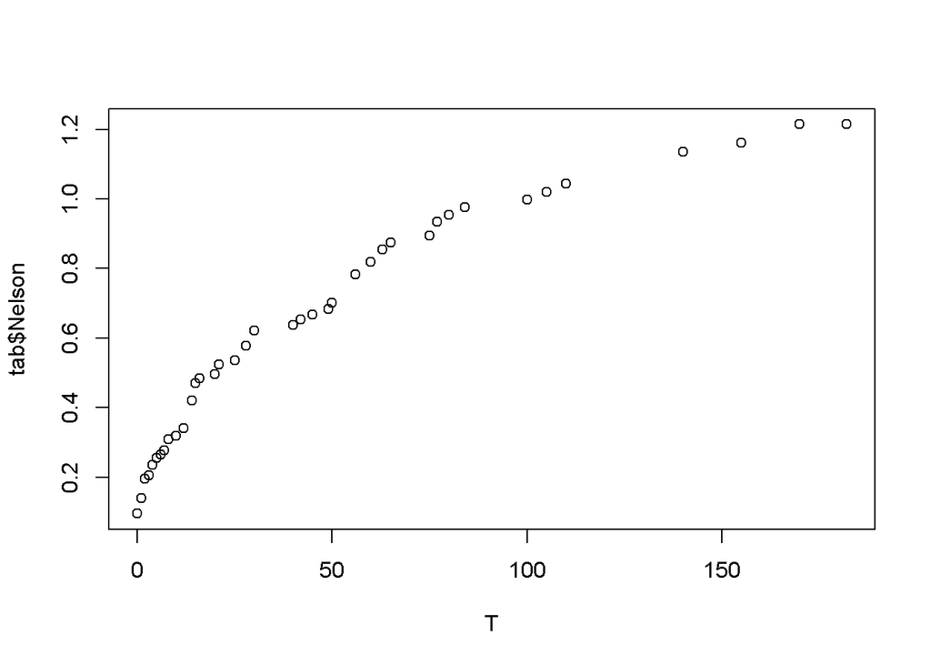

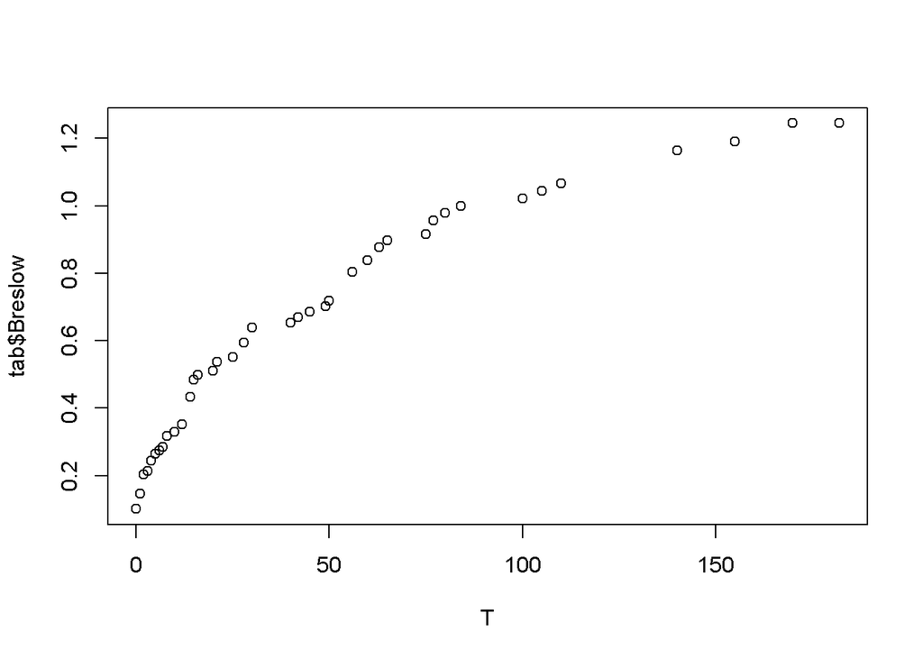

   ```
   ## integer(0)
   ```

   ```r
   #pharmacoSmoking
   tab=estim.Nelson.Breslow(pharmacoSmoking$ttr,pharmacoSmoking$relapse)
   T=sort(unique(pharmacoSmoking$ttr))
   plot(T,tab$Nelson)+
     plot(T,tab$Breslow)
   ```

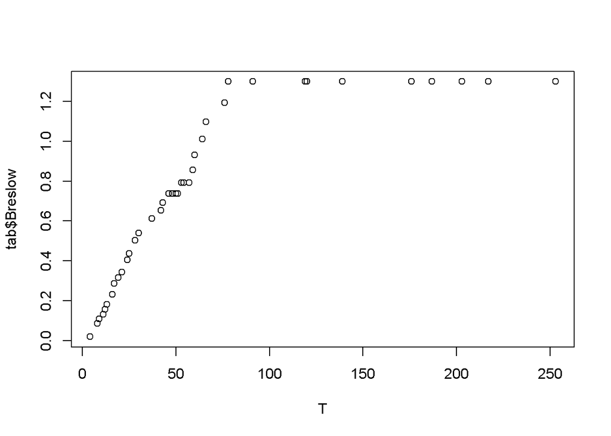

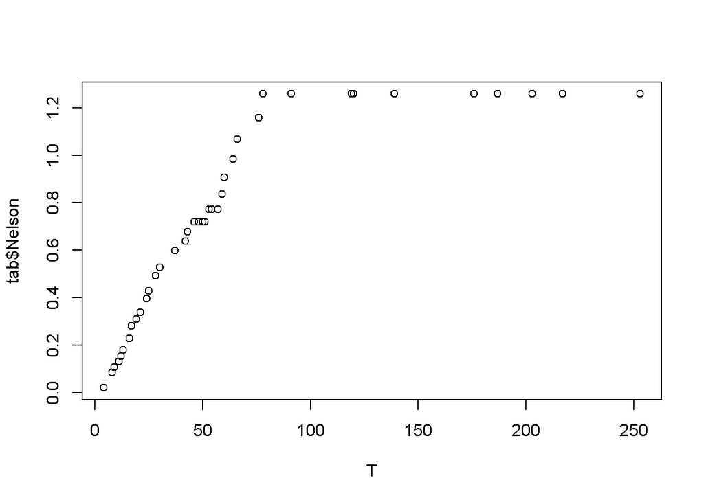

   ```
   ## integer(0)
   ```

   ```r
   #gastriXelox
   tab=estim.Nelson.Breslow(gastricXelox$timeWeeks,gastricXelox$delta)
   T=sort(unique(gastricXelox$timeWeeks))
   plot(T,tab$Breslow)+
     plot(T,tab$Nelson)
   ```

5. Créer une fonction renvoyant l’estimateur de la fonction de survie par la méthode actuarielle. Les pas de temps seront identiques et la fonction prendra en paramètre le nombre de coupures $K.$ On comparera les résultats obtenus avec les résultats de l’estimateur de Kaplan-Meier pour différentes valeurs de $K.$

```r
Estim.Methode.Acturielle = function(temps, delta, K)
{
  a = min(temps)
  b = max(temps)
  pas = (b -a)/K
  tau = seq(a, b, pas)

  ESTIM = 1
  c = list()
  for( i in 1:K+1)
  {
    di = sum(delta[temps == tau[i]])
    cat(di)
    Yi = sum(temps >= tau[i])
    ci = sum(delta[temps == tau[i]] == 0)
    ESTIM = ESTIM * (1 - di/(Yi - (ci/2)))
    c = append(c , ESTIM)
  }
  return(list(tau,c))
}
```

```r
K = 5
res = Estim.Methode.Acturielle(gastricXelox$timeWeeks,gastricXelox$delta, K)
```

```
## 00000
```

```r
# plot(res[1], res[2], 'l')
```

6. Comparrer les résultats obtenus à la question 1 et 2 avec ceux de la fonction `survfit` (package `survival`).

```r
km = survfit(Surv(timeWeeks, delta) ~ 1, data = gastricXelox)
autoplot( km )
km2 = survfit(Surv(ttr, relapse) ~ 1, data = pharmacoSmoking)
autoplot( km2 )
```

[output not shown]

On obtient bien la meme chose . (a la limite on peut rajouter la variance pour voir si la plage est la meme)

# 2 Analyse du jeu de données `pharmacosmoking`

Etudier l’impact des covariables `levelSmoking`, `grp`, `ageGroup2`, `ageGroup4` et `employment`. L’objet de cette question est l’interprétation et la présentation scientifique des résulats que vous avez obtenus, soit par vos fonctions soit par la fonction `survfit` ( voir fonction `summary` et `attributes` appliquées à l’objet de classe `survfit`). On pensera notamment à utiliser des tests et des intervalles de confiance appliqués à quelques instants choisis de l’espace de temps.

```r
#install.packages(c("survival", "survminer"))
library("survival")
library("survminer")
#pharmacosmoking

fit <- survfit(Surv(ttr, relapse) ~ levelSmoking, data = pharmacoSmoking)
print(fit)
```

```
## Call: survfit(formula = Surv(ttr, relapse) ~ levelSmoking, data = pharmacoSmoking)
##
##                     n events median 0.95LCL 0.95UCL
## levelSmoking=heavy 89     62   49.0      15      80
## levelSmoking=light 36     27   50.5      28     140
```

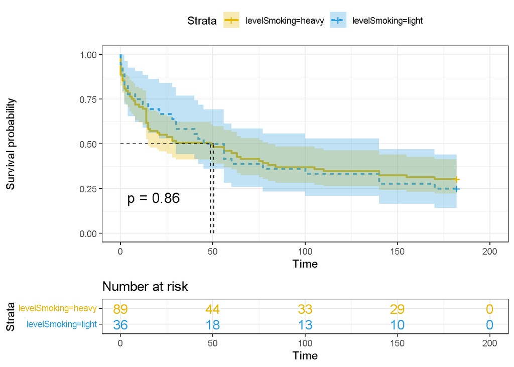

```r
# Change color, linetype by strata, risk.table color by strata
ggsurvplot(fit,
          pval = TRUE, conf.int = TRUE,
          risk.table = TRUE, # Add risk table
          risk.table.col = "strata", # Change risk table color by groups
          linetype = "strata", # Change line type by groups
          surv.median.line = "hv", # Specify median survival
          ggtheme = theme_bw(), # Change ggplot2 theme
          palette = c("#E7B800", "#2E9FDF"))
```

Au fina, sauf au début de l’étude où les gros fumeurs auront plus de chance de reprendre, passé le premier mois, la probabilité de rechuter ne dépend apparament pas de l’intensité à fumé.

```r
fit <- survfit(Surv(ttr, relapse) ~ grp, data = pharmacoSmoking)
print(fit)
```

```
## Call: survfit(formula = Surv(ttr, relapse) ~ grp, data = pharmacoSmoking)
##
##                  n events median 0.95LCL 0.95UCL
## grp=combination 61     37     65      50      NA
## grp=patchOnly   64     52     23      14      56
```

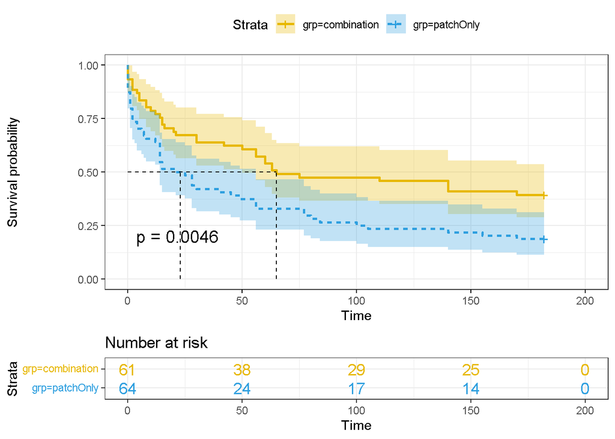

```r
# Change color, linetype by strata, risk.table color by strata
ggsurvplot(fit,
          pval = TRUE, conf.int = TRUE,
          risk.table = TRUE, # Add risk table
          risk.table.col = "strata", # Change risk table color by groups
          linetype = "strata", # Change line type by groups
          surv.median.line = "hv", # Specify median survival
          ggtheme = theme_bw(), # Change ggplot2 theme
          palette = c("#E7B800", "#2E9FDF"))
```

Pour cette classe la on remarque une grosse différence de survie entre le groupe qui a pris seulement les patchs et celui qui a prit une combinaison de patchs et d’autre choses. On pourra donc estimer que la prise d’un complément avec le patch est significatif dans la probabilité d’arret du tabac.

```r
fit <- survfit(Surv(ttr, relapse) ~ employment, data = pharmacoSmoking)
print(fit)
```

```
## Call: survfit(formula = Surv(ttr, relapse) ~ employment, data = pharmacoSmoking)
##
##                   n events median 0.95LCL 0.95UCL
## employment=ft    72     49     56      30     140
## employment=other 39     28     25      12     110
## employment=pt    14     12     18      14      NA
```

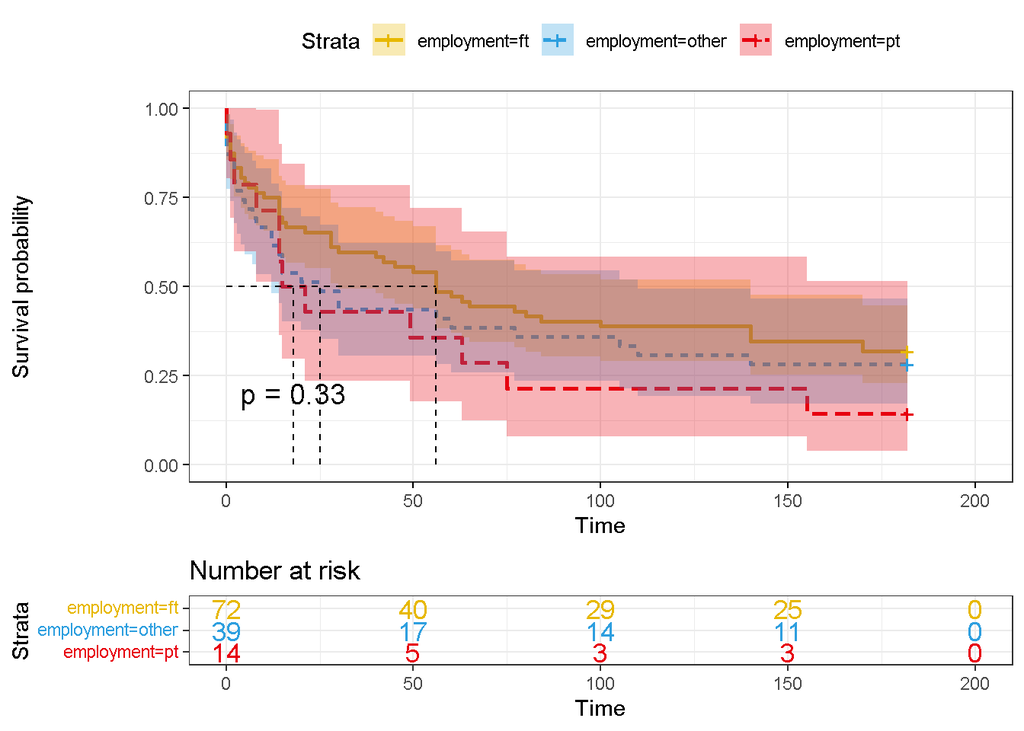

```r
# Change color, linetype by strata, risk.table color by strata
ggsurvplot(fit,
          pval = TRUE, conf.int = TRUE,
          risk.table = TRUE, # Add risk table
          risk.table.col = "strata", # Change risk table color by groups
          linetype = "strata", # Change line type by groups
          surv.median.line = "hv", # Specify median survival
          ggtheme = theme_bw(), # Change ggplot2 theme
          palette = c("#E7B800", "#2E9FDF","#e7000f"))
```

Ici, les travailleurs en temps partiels ont l’air d’avoir plus de mal a tenir contrairement au temps pleins (surement une question de passer le temps).

```r
fit <- survfit(Surv(ttr, relapse) ~ ageGroup2, data = pharmacoSmoking)
print(fit)
```

```
## Call: survfit(formula = Surv(ttr, relapse) ~ ageGroup2, data = pharmacoSmoking)
##
##                  n events median 0.95LCL 0.95UCL
## ageGroup2=21-49 66     56   26.5      14      56
## ageGroup2=50+   59     33   77.0      30      NA
```

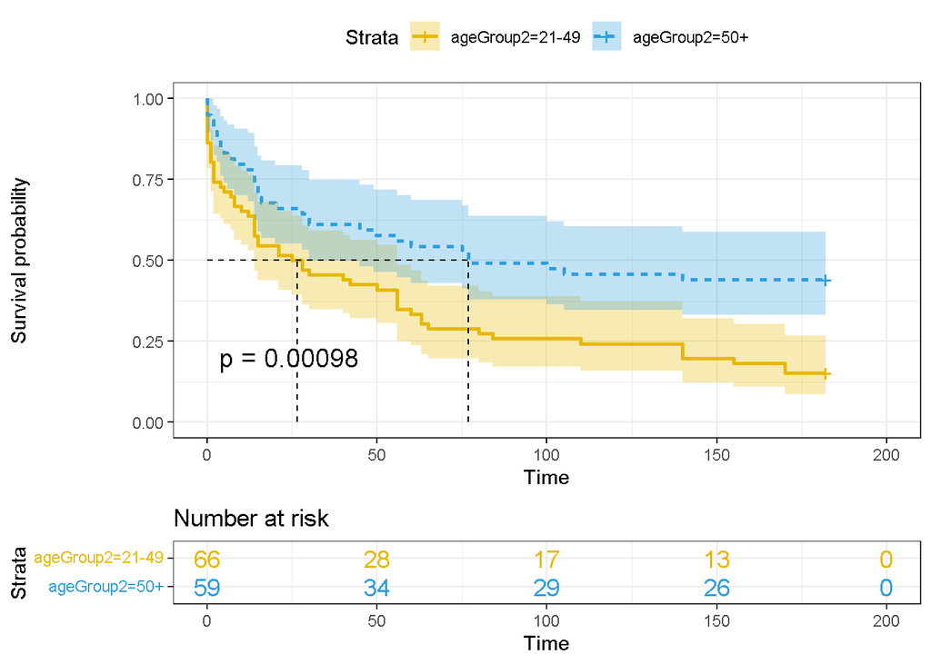

```r
# Change color, linetype by strata, risk.table color by strata
ggsurvplot(fit,
          pval = TRUE, conf.int = TRUE,
          risk.table = TRUE, # Add risk table
          risk.table.col = "strata", # Change risk table color by groups
          linetype = "strata", # Change line type by groups
          surv.median.line = "hv", # Specify median survival
          ggtheme = theme_bw(), # Change ggplot2 theme
          palette = c("#E7B800", "#2E9FDF"))
```

```r
fit <- survfit(Surv(ttr, relapse) ~ ageGroup4, data = pharmacoSmoking)
print(fit)
```

```
## Call: survfit(formula = Surv(ttr, relapse) ~ ageGroup4, data = pharmacoSmoking)
##
##                  n events median 0.95LCL 0.95UCL
## ageGroup4=21-34 16     14     53       5     140
## ageGroup4=35-49 50     42     18      12      63
## ageGroup4=50-64 48     25    122      49      NA
## ageGroup4=65+   11      8     45      20      NA
```

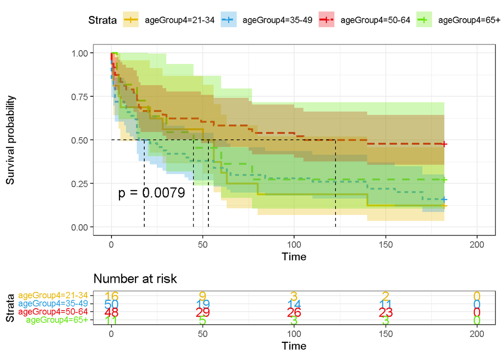

```r
# Change color, linetype by strata, risk.table color by strata
ggsurvplot(fit,
          pval = TRUE, conf.int = TRUE,
          risk.table = TRUE, # Add risk table
          risk.table.col = "strata", # Change risk table color by groups
          linetype = "strata", # Change line type by groups
          surv.median.line = "hv", # Specify median survival
          ggtheme = theme_bw(), # Change ggplot2 theme
          palette = c("#E7B800", "#2E9FDF","#e7000f","#66e60b"))
```

Le shema est un peu lourd mais on arrive à distinguer que la courbe de survie de la classe d’age 50-64 se distingue des autres courbes de survie. On peut donc penser que etre ou non dans cette tranche d’age influe sur le jour de reprise.